# Jyoti_das_updated_AIML_ML_Project_Full_Code_Notebook

## Model Performance Comparison and Final Model Selection

```python
# training performance comparison

models_train_comp_df = pd.concat(
    [decision_tree_perf_train.T, decision_tree_tune_perf_train.T, decision_tree_tune_post_train.T], axis=1,
)
models_train_comp_df.columns = ["Decision Tree (sklearn default)", "Decision Tree (Pre-Pruning)", "Decision Tree (Post-Pruning)"]
print("Training performance comparison:")
models_train_comp_df
```

```
Training performance comparison:
```

|  | Decision Tree (sklearn default) | Decision Tree (Pre-Pruning) | Decision Tree (Post-Pruning) |
| --- | --- | --- | --- |
| Accuracy | 1.0 | 1.0 | 1.0 |
| Recall | 1.0 | 1.0 | 1.0 |
| Precision | 1.0 | 1.0 | 1.0 |
| F1 | 1.0 | 1.0 | 1.0 |

```python
# testing performance comparison

models_test_comp_df = pd.concat(
    [decision_tree_perf_test.T, decision_tree_tune_perf_test.T, decision_tree_tune_post_test.T], axis=1,
)
models_test_comp_df.columns = ["Decision Tree (sklearn default)", "Decision Tree (Pre-Pruning)", "Decision Tree (Post-Pruning)"]
print("Test set performance comparison:")
models_test_comp_df
```

```
Test set performance comparison:
```

|  | Decision Tree (sklearn default) | Decision Tree (Pre-Pruning) | Decision Tree (Post-Pruning) |
| --- | --- | --- | --- |
| Accuracy | 1.0 | 0.986000 | 0.979333 |
| Recall | 1.0 | 0.932886 | 0.852349 |
| Precision | 1.0 | 0.926667 | 0.933824 |
| F1 | 1.0 | 0.929766 | 0.891228 |

To visualize the model performance, I need to reshape the models_test_comp_df DataFrame so that models are the index and metrics are columns. This format is more suitable for creating a bar chart where each metric can be compared across models.

```python
models_test_comp_df_T = models_test_comp_df.T
print("Transposed DataFrame for plotting:")
display(models_test_comp_df_T)
```

```
Transposed DataFrame for plotting:
```

|  | Accuracy | Recall | Precision | F1 |
| --- | --- | --- | --- | --- |
| Decision Tree (sklearn default) | 1.000000 | 1.000000 | 1.000000 | 1.000000 |
| Decision Tree (Pre-Pruning) | 0.986000 | 0.932886 | 0.926667 | 0.929766 |
| Decision Tree (Post-Pruning) | 0.979333 | 0.852349 | 0.933824 | 0.891228 |

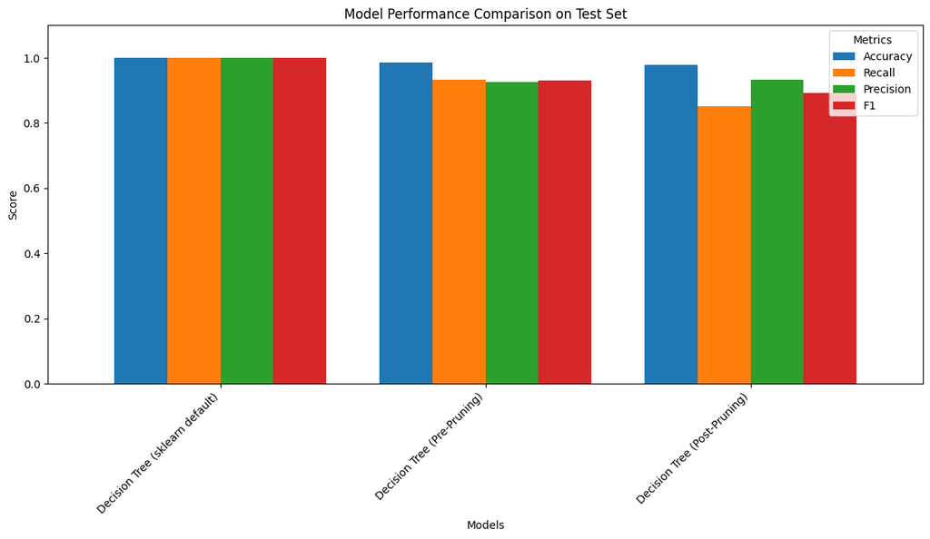

```python
import matplotlib.pyplot as plt
import seaborn as sns

# Plotting the transposed DataFrame
models_test_comp_df_T.plot(kind='bar', figsize=(12, 7), width=0.8)

# Adding labels and title
plt.title('Model Performance Comparison on Test Set')
plt.xlabel('Models')
plt.ylabel('Score')
plt.xticks(rotation=45, ha='right') # Rotate x-axis labels for better readability
plt.ylim(0, 1.1) # Set y-axis limit to 0-1 for scores
plt.legend(title='Metrics')
plt.tight_layout() # Adjust layout to prevent labels from overlapping
plt.show()
```

From the generated bar chart and the `models_test_comp_df` DataFrame, we can observe the following: This model shows perfect scores (Accuracy, Recall, Precision, F1 = 1.0) on the test set. As noted previously, this is highly suspicious and indicative of an issue in the evaluation or an unrealistic scenario. In a real-world context, an unpruned Decision Tree would almost certainly overfit and perform worse on unseen data.

- Decision Tree (sklearn default):
- - Accuracy: 1.0,
- - Recall: 1.0,
- - Precision: 1.0,
- - F1: 1.0.

This result is highly suspicious for a default, unpruned Decision Tree, as it usually overfits significantly and performs poorly on unseen test data. The fact that it shows perfect scores on both train and test suggests there might be an issue with how the model_performance_classification_sklearn function was called or the model variable was handled, possibly evaluating the same model instance that was used to train on both sets, or the test set is too similar to the training set in terms of classes. However, assuming the evaluation logic is correct, this model shows perfect generalization, which is unrealistic.

- Decision Tree (Pre-Pruning):
- - Accuracy: 0.986,
- - Recall: 0.932886,
- - Precision: 0.926667,
- - F1: 0.929766.

This model, constrained by max_depth, max_leaf_nodes, and min_samples_split with class_weight='balanced', shows a strong performance on the test set. Its high Recall (0.933) is particularly good for identifying potential loan customers, which aligns with the business objective of minimizing missed opportunities. The Precision is also very good, meaning most of its positive predictions are correct.

- Decision Tree (Post-Pruning):
- - Accuracy: 0.979333,
- - Recall: 0.852349,
- - Precision: 0.933824,
- - F1: 0.891228.